# World Economic Analysis

Lohansen

2019-09-03

# Brief

Data : Economic Freedom of the World Role : Government Urban Data Analyst Target : mengetahui faktor-faktor apa saja yang mempengaruhi index economic freedom suatu negara, dan melakukan clustering/pengelompokan pada negara-negara yang memiliki kesamaan Source : https://www.kaggle.com/gsutters/economic-freedom/downloads/economic-freedom.zip/1

Data Introduction Indeks yang diterbitkan dalam Kebebasan Ekonomi Dunia oleh Fraser Institute mengukur sejauh mana kebijakan dan lembaga negara mendukung kebebasan ekonomi. Landasan kebebasan ekonomi adalah pilihan pribadi, pertukaran sukarela, kebebasan untuk memasuki pasar dan bersaing, dan keamanan orang dan properti yang dimiliki secara pribadi. Empat puluh dua titik data digunakan untuk membuat ringkasan indeks dan untuk mengukur tingkat kebebasan ekonomi di lima area pemerintahan luas.

Berikut pembagian Area ukuran indeks ini - Area 1: Ukuran Pemerintah - Seiring pengeluaran pemerintah, perpajakan, dan ukuran perusahaan yang dikendalikan pemerintah meningkat, pengambilan keputusan pemerintah digantikan dengan pilihan individu dan kebebasan ekonomi berkurang.

- Area 2: Sistem Hukum dan Hak Milik - Perlindungan orang dan properti yang diperoleh secara sah merupakan elemen sentral dari kebebasan ekonomi dan masyarakat sipil. Memang, itu adalah fungsi pemerintah yang paling penting.
- Area 3: Uang Sehat - Inflasi mengikis nilai upah dan tabungan yang seharusnya diperoleh. Uang yang sehat sangat penting untuk melindungi hak milik. Ketika inflasi tidak hanya tinggi tetapi juga mudah berubah, menjadi sulit bagi individu untuk merencanakan masa depan dan dengan demikian menggunakan kebebasan ekonomi secara efektif.
- Area 4: Kebebasan Berdagang Secara Internasional - Kebebasan untuk bertukar — dalam arti luas, membeli, menjual, membuat kontrak, dan sebagainya — sangat penting bagi kebebasan ekonomi, yang berkurang ketika kebebasan bertukar tidak termasuk bisnis dan individu di negara lain .
- Area 5: Regulasi - Pemerintah tidak hanya menggunakan sejumlah alat untuk membatasi hak untuk bertukar internasional, mereka juga dapat mengembangkan peraturan yang memberatkan, membatasi hak untuk bertukar, mendapatkan kredit, mempekerjakan atau bekerja sesuai keinginan Anda, atau secara bebas mengoperasikan bisnis Anda .

# Library

```r
library(dplyr)
library(tidyverse)
library(FactoMineR)
```

# Data Exploratory

Read Data

```r
economic <- read.csv("efw_cc.csv")
```

Preparing the data for K-Means Clustering

```r
economic.2016 <- economic %>%
  filter(year == "2016") %>%
  select(-c(ISO_code, rank, year, quartile, ECONOMIC.FREEDOM))

name <- sub(pattern = "X", replacement = "", x = colnames(economic.2016))
name <- sub(pattern = "\\d", replacement = "", x = name)
name <- sub(pattern = "_", replacement = "", x = name)
name <- sub(pattern = "\\w", replacement = "", x = name)
colnames(economic.2016) <- name
economic.2016 <- data.frame(economic.2016, row.names = 1)

economic.2016 <- economic.2016 %>%
  select(-c( integrity_legal_system, reliability_police, transfers, protection_property_rights, business_costs_crime, judicial_independence, restrictions_sale_real_property, tariffs, black_market, judicial_independence, impartial_courts, ize_government, control_movement_capital_ppl, egulation, business_reg, labor_market_reg, credit_market_reg, ound_money))
```

checking NA

```r
colSums(is.na(economic.2016))
```

```
##       government_consumption              gov_enterprises
##                            0                            5
##            top_marg_tax_rate        military_interference
##                            0                            0
##  legal_enforcement_contracts            gender_adjustment
##                            0                            0
##               roperty_rights                 money_growth
##                            0                            0
##                std_inflation                    inflation
##                            0                            0
## freedom_own_foreign_currency    regulatory_trade_barriers
##                            0                            0
##                         rade
##                            0
```

drop NA

```r
economic.2016 <- economic.2016 %>%
  select(-gov_enterprises)
```

# Modelling

### K-Means + PCA

K-Means Modelling

```r
wss <- function(data, maxCluster = 9) {
    # Initialize within sum of squares
    SSw <- (nrow(data) - 1) * sum(apply(data, 2, var))
    SSw <- vector()
    set.seed(100)
    for (i in 2:maxCluster) {
        SSw[i] <- sum(kmeans(data, centers = i)$withinss)
    }
    plot(1:maxCluster, SSw, type = "o", xlab = "Number of Clusters", ylab = "Within groups sum of squares", pch=19)
}
```

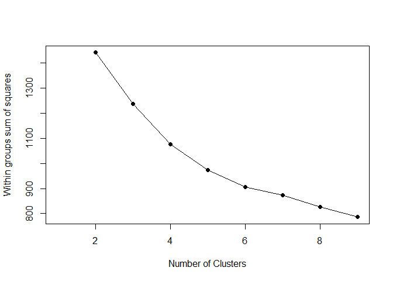

```r
# set.seed(100)
economic.2016.s <- scale(economic.2016)
wss(economic.2016.s)
```

Note : Berdasarkan plot diatas say amengambil kesimpulan bahwa elbow point atau titik perpotongan berada di titik no.4

K = 4

```r
set.seed(100)
economic.km <- kmeans(economic.2016, 4)
```

PCA

```r
economic.2016.new <- economic.2016
economic.2016.new$cluster <- as.factor(economic.km$cluster)
```

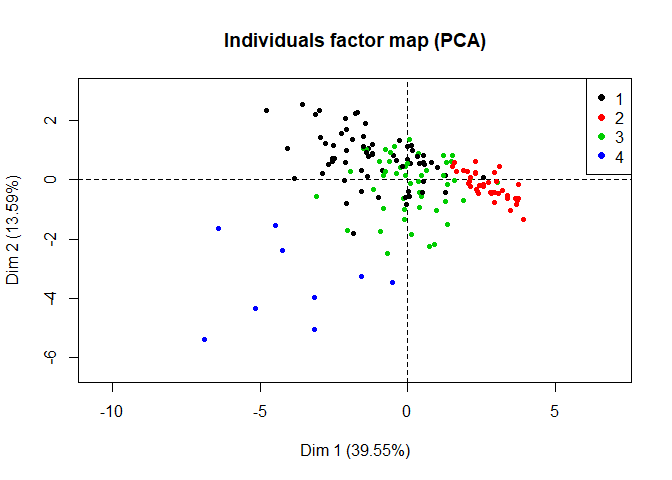

```r
economic.pca<-PCA(economic.2016.s, graph = F)
plot(economic.pca, choix=c("ind"), label="none", col.ind=economic.2016.new$cluster)
legend("topright", levels(economic.2016.new$clust), pch=19, col=1:4)
```

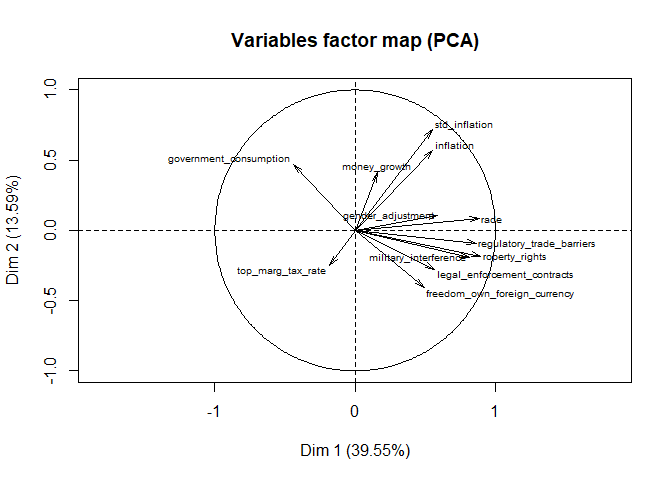

```r
plot(economic.pca, cex=0.6, choix="var", col.ind=economic.2016.new$cluster)
```

# Basic PCA (Prcomp)

```r
economic.pca2 <- prcomp(economic.2016)
summary(economic.pca2)
```

```
## Importance of components:
##                           PC1    PC2    PC3     PC4     PC5     PC6
## Standard deviation     4.6971 3.2653 2.3427 2.09648 1.65078 1.44717
## Proportion of Variance 0.4293 0.2075 0.1068 0.08553 0.05303 0.04075
## Cumulative Proportion  0.4293 0.6368 0.7436 0.82915 0.88218 0.92293
##                            PC7     PC8     PC9    PC10    PC11    PC12
## Standard deviation     1.25077 1.03211 0.89173 0.57650 0.43754 0.10775
## Proportion of Variance 0.03044 0.02073 0.01547 0.00647 0.00373 0.00023
## Cumulative Proportion  0.95338 0.97411 0.98958 0.99605 0.99977 1.00000
```

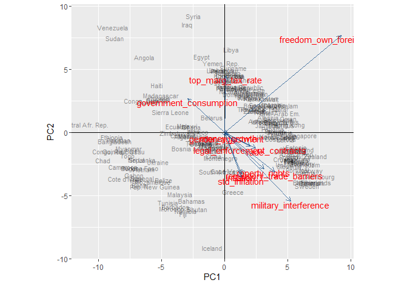

```r
source("biplot.R")
fancy_biplot(economic.pca2)
```

Interpretasi : - negara-negara di cluster kanan atas memiliki kemiripan di bidang freedom own forign yang tinggi - negara-negara di cluster kiris bawah memiliki freedom own forign yang rendah karena berlawanan arah - Negara Libta memiliki tingkat freedom own foreign yang cukup tinggi - Negara Sweden dan Greece memiliki tingkat military interfence yang cukup tinggi